# Data Sience Projekt WS24 - Dream Team

#### Import of required libraries

```python
import spacy
import pandas as pd
import matplotlib.pyplot as plt
import seaborn as sns
from wordcloud import WordCloud
from spacy import displacy
from transformers import pipeline
from germansentiment import SentimentModel
from datasets import Dataset
from tqdm import tqdm
import time
import numpy as np

import ast
from itertools import combinations
import networkx as nx
from pyvis.network import Network
import datetime
```

#### Import of scraped articles file

```python
# Path to the CSV file
#file_path = "../data/articles_24.csv"
file_path = "articles_24.csv"
# Read the CSV file into a DataFrame
df = pd.read_csv(file_path)
```

## Data Cleaning

##### File Information

```python
df.info()
```

```
<class 'pandas.core.frame.DataFrame'>
RangeIndex: 47784 entries, 0 to 47783
Data columns (total 6 columns):
 #   Column        Non-Null Count  Dtype
---  ------        --------------  -----
 0   title         47784 non-null  object
 1   authors       47784 non-null  object
 2   date_publish  47784 non-null  object
 3   maintext      47368 non-null  object
 4   url           47784 non-null  object
 5   newspaper     47784 non-null  object
dtypes: object(6)
memory usage: 2.2+ MB
```

```python
df.head()
```

|  | title | authors | date_publish | maintext | url | newspaper |
| --- | --- | --- | --- | --- | --- | --- |
| 0 | Yvonne Woelke wollte ein Baby: Kehrtwende! „Ki... | ['Tanja May'] | 2024-01-01 22:00:02 | „Ich wünsche mir nichts sehnlicher, als endlic... | https://www.bild.de/bild-plus/unterhaltung/leu... | bild.de |
| 1 | RB Leipzig: Es wurde über Instagram öffentlich... | ['Yvonne Gabriel'] | 2024-01-01 22:36:21 | Stammplatz weg, ungewisse Zukunft. Sportlich l... | https://www.bild.de/sport/fussball/rb-leipzig/... | bild.de |
| 2 | Apple Watch 8 mit Alu-Sportband beim BILDplus ... | ['BILD'] | 2024-01-02 08:06:51 | Frohes Neues liebe BILDplus-User! Damit der St... | https://www.bild.de/gewinnspiele/bildplus-akti... | bild.de |
| 3 | Werder Bremen: „1000-mal totgesagt“ - Ein Prof... | ['Markus Balczuweit'] | 2024-01-01 22:12:40 | Christian Groß (34) ist unverwüstlich.\r\nWerd... | https://www.bild.de/sport/fussball/werder-brem... | bild.de |
| 4 | Angelique Kerber: Kaum zu glauben, wer in der ... | ['SEBASTIAN KAYSER'] | 2024-01-01 22:43:31 | Tennis-Start ins Neue Jahr! In Australien spie... | https://www.bild.de/sport/mehr-sport/tennis/an... | bild.de |

##### Delete articles that cant meet the requirements:

```python
# Function to check if maintext is valid
def is_valid_article(text):
    # Ensure the text is a string
    if not isinstance(text, str):
        return False

    # Check word count
    word_count = len(text.split())
    if word_count < 300:
        return False

    # Check for repeated sentences
    sentences = text.split('. ')
    for i in range(len(sentences) - 1):
        if sentences[i].strip() == sentences[i + 1].strip():
            return False

    return True

# Apply the function to filter the DataFrame
df = df[df["maintext"].apply(is_valid_article)]

# Reset the index
df = df.reset_index(drop=True)
```

##### From 47784 Articles down to 11242. Ensuring article quality

```python
df.info()
```

```
<class 'pandas.core.frame.DataFrame'>
RangeIndex: 11242 entries, 0 to 11241
Data columns (total 6 columns):
 #   Column        Non-Null Count  Dtype
---  ------        --------------  -----
 0   title         11242 non-null  object
 1   authors       11242 non-null  object
 2   date_publish  11242 non-null  object
 3   maintext      11242 non-null  object
 4   url           11242 non-null  object
 5   newspaper     11242 non-null  object
dtypes: object(6)
memory usage: 527.1+ KB
```

##### Changing format of date. And also from Authors. In case of necessity for future Analysis.

```python
#Standarize date format
df['date_publish'] = pd.to_datetime(df['date_publish'], format='%Y-%m-%d %H:%M:%S', errors='coerce')
```

```python
# Function to format authors
def format_authors(authors):
    if not isinstance(authors, str):
        return authors  # Skip non-string values

    # Convert to title case
    formatted = authors.title()

    # Replace "und" with ", "
    formatted = formatted.replace(", ", "', '") # fix the commas and quotes position
    formatted = formatted.replace(" Und", "', '") # fix various ways to say 'und'
    formatted = formatted.replace(" &", "', '") # fix various ways to say 'und'
    formatted = formatted.replace("''", "'") # fix the double quotes

    # Remove "Von" or "von" from the start of words
    if formatted.startswith("['Von"):
        formatted = "['" + formatted[5:].strip()

    return formatted

# Apply the function to the 'authors' column
df["authors"] = df["authors"].apply(format_authors)
```

```python
df.head(15)
```

|  | title | authors | date_publish | maintext | url | newspaper |
| --- | --- | --- | --- | --- | --- | --- |
| 0 | RB Leipzig: Es wurde über Instagram öffentlich... | ['Yvonne Gabriel'] | 2024-01-01 22:36:21 | Stammplatz weg, ungewisse Zukunft. Sportlich l... | https://www.bild.de/sport/fussball/rb-leipzig/... | bild.de |
| 1 | Apple Watch 8 mit Alu-Sportband beim BILDplus ... | ['Bild'] | 2024-01-02 08:06:51 | Frohes Neues liebe BILDplus-User! Damit der St... | https://www.bild.de/gewinnspiele/bildplus-akti... | bild.de |
| 2 | Angelique Kerber: Kaum zu glauben, wer in der ... | ['Sebastian Kayser'] | 2024-01-01 22:43:31 | Tennis-Start ins Neue Jahr! In Australien spie... | https://www.bild.de/sport/mehr-sport/tennis/an... | bild.de |
| 3 | FC Bayern: Ungewohntes Programm! So starten di... | ['Nico Linner'] | 2024-01-01 22:15:11 | Dieser Start in 2024 hat es in sich!\r\nHeute ... | https://www.bild.de/sport/fussball/bayern-muen... | bild.de |
| 4 | Putin gefährlich wie nie: Brauchen wir jetzt s... | ['Sebastian Geisler'] | 2024-01-01 21:53:49 | Muss Europa JETZT drastisch aufrüsten?\r\nKrem... | https://www.bild.de/politik/ausland/politik-au... | bild.de |
| 5 | CDU-Generalsekretär Carsten Linnemann fordert:... | ['Bild'] | 2024-01-01 21:50:22 | Klare Worte von Carsten Linnemann (46)!\r\nDer... | https://www.bild.de/politik/inland/politik-inl... | bild.de |
| 6 | Darts-WM: Wunderkind Luke Littler macht seine ... | ['Max Schrader', ' Jonas Ortmann'] | 2024-01-01 21:33:47 | Luke Littler (16) steht sensationell im Halbfi... | https://www.bild.de/sport/mehr-sport/darts/dar... | bild.de |
| 7 | Praktikum bei Preußen: Daube macht den Sportfa... | ['Joachim Schuth'] | 2024-01-01 20:29:11 | Vor genau 233 Tagen hatte Dennis Daube (34) se... | https://www.bild.de/sport/fussball/fussball/pr... | bild.de |
| 8 | Gunnar Schupelius - Mein Ärger: Die Regierung ... | ['Gunnar Schupelius'] | 2024-01-01 20:27:57 | BERLIN – Die Klimapolitik ist einem Automatism... | https://www.bild.de/regional/berlin/berlin-akt... | bild.de |
| 9 | Darts-WM: Wunderkind Luke Littler steht im Hal... | ['Max Schrader', ' Jonas Ortmann'] | 2024-01-01 20:21:05 | Er macht die Sport-Welt sprachlos.\r\nDer 16-j... | https://www.bild.de/sport/mehr-sport/darts/dar... | bild.de |
| 10 | Carmen Nebel: Jetzt hat sich auch ihr Sohn (38... | ['Iris Rosendahl'] | 2024-01-01 20:18:11 | Süßer die Hochzeitsglocken bald klingen …\r\nE... | https://www.bild.de/unterhaltung/leute/leute/c... | bild.de |
| 11 | Silvester-Bilanz: 54 verletzte Polizisten, 30 ... | ['Axel Lier'] | 2024-01-01 19:46:53 | Berlin – Ein Großaufgebot der Polizei verhinde... | https://www.bild.de/regional/berlin/berlin-akt... | bild.de |
| 12 | Betrug mit Bitcoins: Rentner verlor seine ganz... | ['Karsten Kehr'] | 2024-01-01 19:58:31 | Buttstädt (Thüringen) – „Bei diesen Summen wir... | https://www.bild.de/regional/thueringen/thueri... | bild.de |
| 13 | Bürgergeld statt Krieg: 200 000 potentielle Uk... | ['Marc Oliver Rühle'] | 2024-01-01 19:32:18 | Boss von Milliarden-Konzern vor Luxus-Hotel in... | https://www.bild.de/politik/inland/politik-inl... | bild.de |
| 14 | Nationalmannschaft: Deutet Toni Kroos hier DFB... | ['Kilian Gaffrey'] | 2024-01-01 17:52:20 | Welche geheime Botschaft steckt hinter diesem ... | https://www.bild.de/sport/fussball/nationalman... | bild.de |

#### Usage of German Sentiment Classification with Bert. From Hugging face, adding a sentiment value to each news article in the dataframe.

##### Saved in a CSV File, because classification process takes too much time to be running every work session on the notebook.

```python
# 1. Datei laden
df = pd.read_csv(file_path)
###df = df.head(100)  # Nur die ersten 100 Zeilen verwenden

# 2. Sentiment-Analyzer laden
sentiment_analyzer = pipeline("sentiment-analysis", model="oliverguhr/german-sentiment-bert")

# 3. Sentiment-Analyse auf die Spalte 'article' anwenden
df['sentiment'] = df['maintext'].apply(lambda x: sentiment_analyzer(x[:512])[0]['label'])

# 4. Ergebnisse überprüfen
print(df[['maintext', 'sentiment']].head())

# 5. Datei mit Ergebnissen speichern
df.to_csv("out_with_sentiment_2.csv", index=False)
print("Datei wurde gespeichert als 'out_with_sentiment_2.csv'.")
```

##### Dataframe with now added Sentiment Value

```python
df_sentiment = pd.read_csv("out_with_sentiment_2.csv")
```

```python
df_sentiment.head(15)
```

|  | title | authors | date_publish | maintext | url | newspaper | sentiment |
| --- | --- | --- | --- | --- | --- | --- | --- |
| 0 | RB Leipzig: Es wurde über Instagram öffentlich... | ['Yvonne Gabriel'] | 2024-01-01 22:36:21 | Stammplatz weg, ungewisse Zukunft. Sportlich l... | https://www.bild.de/sport/fussball/rb-leipzig/... | bild.de | negative |
| 1 | Apple Watch 8 mit Alu-Sportband beim BILDplus ... | ['Bild'] | 2024-01-02 08:06:51 | Frohes Neues liebe BILDplus-User! Damit der St... | https://www.bild.de/gewinnspiele/bildplus-akti... | bild.de | neutral |
| 2 | Angelique Kerber: Kaum zu glauben, wer in der ... | ['Sebastian Kayser'] | 2024-01-01 22:43:31 | Tennis-Start ins Neue Jahr! In Australien spie... | https://www.bild.de/sport/mehr-sport/tennis/an... | bild.de | negative |
| 3 | FC Bayern: Ungewohntes Programm! So starten di... | ['Nico Linner'] | 2024-01-01 22:15:11 | Dieser Start in 2024 hat es in sich!\nHeute ha... | https://www.bild.de/sport/fussball/bayern-muen... | bild.de | negative |
| 4 | Putin gefährlich wie nie: Brauchen wir jetzt s... | ['Sebastian Geisler'] | 2024-01-01 21:53:49 | Muss Europa JETZT drastisch aufrüsten?\nKreml-... | https://www.bild.de/politik/ausland/politik-au... | bild.de | neutral |
| 5 | CDU-Generalsekretär Carsten Linnemann fordert:... | ['Bild'] | 2024-01-01 21:50:22 | Klare Worte von Carsten Linnemann (46)!\nDer C... | https://www.bild.de/politik/inland/politik-inl... | bild.de | neutral |
| 6 | Darts-WM: Wunderkind Luke Littler macht seine ... | ['Max Schrader', ' Jonas Ortmann'] | 2024-01-01 21:33:47 | Luke Littler (16) steht sensationell im Halbfi... | https://www.bild.de/sport/mehr-sport/darts/dar... | bild.de | negative |
| 7 | Praktikum bei Preußen: Daube macht den Sportfa... | ['Joachim Schuth'] | 2024-01-01 20:29:11 | Vor genau 233 Tagen hatte Dennis Daube (34) se... | https://www.bild.de/sport/fussball/fussball/pr... | bild.de | neutral |
| 8 | Gunnar Schupelius - Mein Ärger: Die Regierung ... | ['Gunnar Schupelius'] | 2024-01-01 20:27:57 | BERLIN – Die Klimapolitik ist einem Automatism... | https://www.bild.de/regional/berlin/berlin-akt... | bild.de | neutral |
| 9 | Darts-WM: Wunderkind Luke Littler steht im Hal... | ['Max Schrader', ' Jonas Ortmann'] | 2024-01-01 20:21:05 | Er macht die Sport-Welt sprachlos.\nDer 16-jäh... | https://www.bild.de/sport/mehr-sport/darts/dar... | bild.de | positive |
| 10 | Carmen Nebel: Jetzt hat sich auch ihr Sohn (38... | ['Iris Rosendahl'] | 2024-01-01 20:18:11 | Süßer die Hochzeitsglocken bald klingen …\nErs... | https://www.bild.de/unterhaltung/leute/leute/c... | bild.de | neutral |
| 11 | Silvester-Bilanz: 54 verletzte Polizisten, 30 ... | ['Axel Lier'] | 2024-01-01 19:46:53 | Berlin – Ein Großaufgebot der Polizei verhinde... | https://www.bild.de/regional/berlin/berlin-akt... | bild.de | neutral |
| 12 | Betrug mit Bitcoins: Rentner verlor seine ganz... | ['Karsten Kehr'] | 2024-01-01 19:58:31 | Buttstädt (Thüringen) – „Bei diesen Summen wir... | https://www.bild.de/regional/thueringen/thueri... | bild.de | negative |
| 13 | Bürgergeld statt Krieg: 200 000 potentielle Uk... | ['Marc Oliver Rühle'] | 2024-01-01 19:32:18 | Boss von Milliarden-Konzern vor Luxus-Hotel in... | https://www.bild.de/politik/inland/politik-inl... | bild.de | neutral |
| 14 | Nationalmannschaft: Deutet Toni Kroos hier DFB... | ['Kilian Gaffrey'] | 2024-01-01 17:52:20 | Welche geheime Botschaft steckt hinter diesem ... | https://www.bild.de/sport/fussball/nationalman... | bild.de | neutral |

## Entity Extraction through spacy

##### With the Spacy Python Library, extraction of entities of each news article, added as an extra column to dataframe.

```python
# Load language model
nlp = spacy.load("de_core_news_md")
```

```python
# Function to extract entities from text
def extract_entities(text):
    doc = nlp(text)  # Process text with spaCy
    entities = [(ent.text, ent.label_) for ent in doc.ents]  # Extract entities and labels
    return entities

# Function to process data with progress tracking for entity extraction
def process_with_progress(df):
    start_time = time.time()  # Track the start time
    all_entities = []

    # Initialize tqdm with time tracking for each entry
    with tqdm(total=len(df), desc="Processing Text", ncols=100) as pbar:
        for index, row in df.iterrows():  # Use iterrows() to iterate over DataFrame rows
            text = row['maintext']
            # Extract entities for each row
            entities = extract_entities(text)

            # Append results
            all_entities.append(entities)

            # Update progress bar and calculate time left
            elapsed_time = time.time() - start_time
            estimated_time_left = (elapsed_time / (index + 1)) * (len(df) - (index + 1))
            pbar.set_postfix({"Time Left": f"{estimated_time_left / 60:.2f} min"})
            pbar.update(1)

    # Create a new dataframe copy called df_pipeline
    df_pipeline = df.copy()

    # Add the results to the dataframe
    df_pipeline['entities'] = all_entities

    return df_pipeline

# Apply the function to process the dataframe with progress tracking
df_pipeline = process_with_progress(df)
```

```python
df_sentiment = df_sentiment.join(df_pipeline[["entities"]])
```

##### Distribution of Sentiment Values.

```python
if 'sentiment' in df_sentiment.columns:
    sentiment_counts = df_sentiment['sentiment'].explode().value_counts()
    print(sentiment_counts)
else:
    print("The 'sentiment' column does not exist in df_copy.")
```

```
sentiment
neutral     8328
negative    2643
positive     271
Name: count, dtype: int64
```

### Extraction of Entities mapped to Sentiment Value

```python
entity_sentiment_mapping = df_sentiment[['entities', 'sentiment']].copy()
```

```python
entity_sentiment_mapping.head()
```

|  | entities | sentiment |
| --- | --- | --- |
| 0 | [(Timo Werner, PER), (Paula Lense, PER), (Dres... | negative |
| 1 | [(Frohes, PER), (Neues liebe BILDplus-User!, M... | neutral |
| 2 | [(Tennis-Start ins Neue Jahr, MISC), (Australi... | negative |
| 3 | [(FC Bayern, ORG), (Harry Kane, PER), (Thomas ... | negative |
| 4 | [(Kreml-Tyrann Wladimir Putin, PER), (Ukraine,... | neutral |

#### Mapping each Entity pair with the sentiment of the article.

##### Assuming that Sentiment of Article may be assigned to each entity. Needed for future analysis.

```python
# Create an empty list to store the new rows
new_rows = []

# Iterate over the rows of the original DataFrame
for index, row in entity_sentiment_mapping.iterrows():
    # Check if the 'entities' column is not null and is a list
    if isinstance(row['entities'], list) and row['entities'] is not None:
        # Iterate over the entities in the list (without using set for unique values)
        for entity in row['entities']:
            # Create a new row with the entity and the original sentiment
            new_row = {
                'entity': entity,
                'sentiment': row['sentiment']
            }
            new_rows.append(new_row)

# Create a new DataFrame from the new rows
entity_sentiment_mapping = pd.DataFrame(new_rows)
entity_sentiment_mapping
```

|  | entity | sentiment |
| --- | --- | --- |
| 0 | (Timo Werner, PER) | negative |
| 1 | (Paula Lense, PER) | negative |
| 2 | (Dresdnerin, LOC) | negative |
| 3 | (Dieses Jahr, MISC) | negative |
| 4 | (Sieben Jahre, MISC) | negative |
| ... | ... | ... |
| 428877 | (Steffen Bilger, PER) | negative |
| 428878 | (BaWü, ORG) | negative |
| 428879 | (BILD, ORG) | negative |
| 428880 | (Der Vorfall, MISC) | negative |
| 428881 | (Deutschland, LOC) | negative |

428882 rows × 2 columns

#### Deleting repeated rows, but adding a count for each repeated Value to represent weight.

```python
entity_sentiment_mapping = entity_sentiment_mapping.groupby(['entity', 'sentiment']).size().reset_index(name='count')
entity_sentiment_mapping = entity_sentiment_mapping.sort_values(by='count', ascending=False)
entity_sentiment_mapping.head()
```

|  | entity | sentiment | count |
| --- | --- | --- | --- |
| 9725 | (BILD, ORG) | neutral | 8589 |
| 111646 | (Scholz, PER) | neutral | 4772 |
| 18596 | (Bundestag, ORG) | neutral | 4706 |
| 30195 | (Deutschland, LOC) | neutral | 3120 |
| 62520 | (Iran, LOC) | neutral | 2326 |

##### Distribution of Values. (Based on Entity)

```python
sentiment_counts = entity_sentiment_mapping.groupby('sentiment')['count'].sum()
sentiment_counts
```

| sentiment | count |
| --- | --- |
| negative | 94320 |
| neutral | 324923 |
| positive | 9639 |

**dtype:** int64

## Visualization of Results

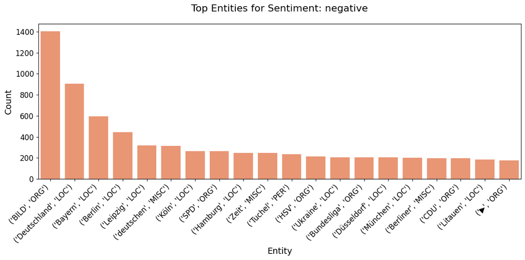

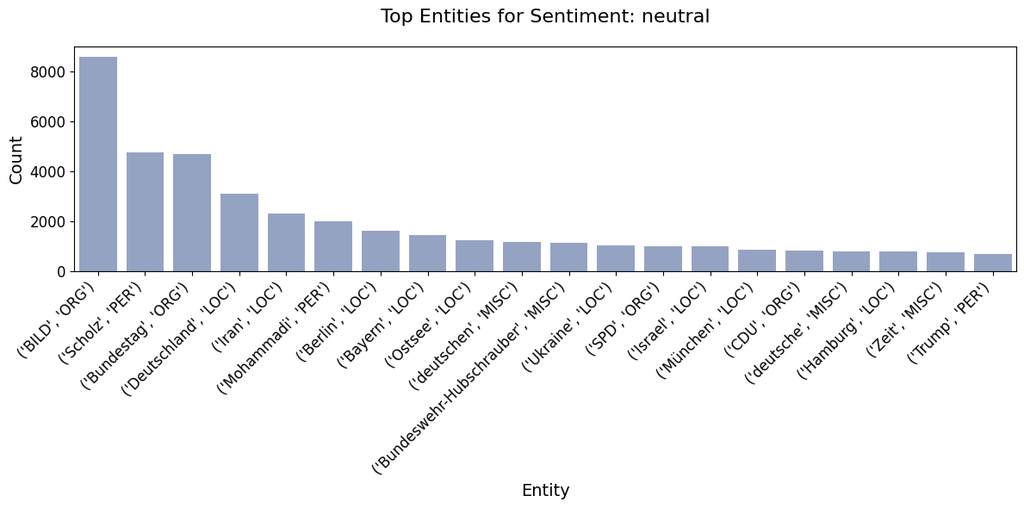

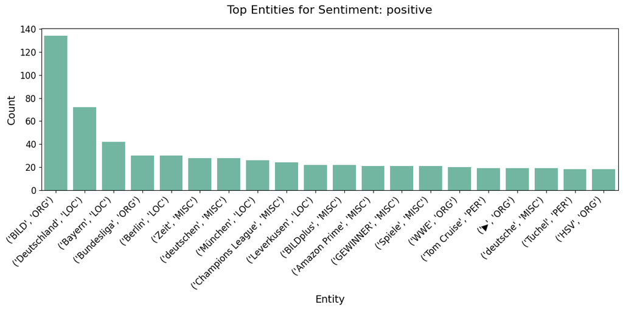

```python
import matplotlib.pyplot as plt
import seaborn as sns

# Define the custom color palette for each sentiment
colors = {'positive': '#66c2a5', 'negative': '#fc8d62', 'neutral': '#8da0cb'}

# Group the data for visualization
sentiment_entity_counts = entity_sentiment_mapping.groupby(['sentiment', 'entity'])['count'].sum().reset_index()

# Create a plot for each sentiment value
for sentiment in sentiment_entity_counts['sentiment'].unique():
    # Filter data for the current sentiment
    sentiment_data = sentiment_entity_counts[sentiment_entity_counts['sentiment'] == sentiment]

    # Sort the entities by count
    sentiment_data = sentiment_data.sort_values('count', ascending=False).head(20)  # Limit to top 20 for clarity

    plt.figure(figsize=(12, 6))  # Adjust figure size for better visualization

    # Convert 'entity' column to string type before plotting
    sentiment_data['entity'] = sentiment_data['entity'].astype(str)

    # Create the bar plot with custom color
    sns.barplot(
        x='entity',
        y='count',
        data=sentiment_data,
        color=colors[sentiment]  # Use the sentiment-specific color
    )

    # Add title and labels with enhanced formatting
    plt.title(f'Top Entities for Sentiment: {sentiment}', fontsize=16, pad=20)
    plt.xlabel('Entity', fontsize=14)
    plt.ylabel('Count', fontsize=14)

    # Rotate x-axis labels for better readability
    plt.xticks(rotation=45, ha='right', fontsize=12)
    plt.yticks(fontsize=12)

    # Adjust layout to prevent overlap
    plt.tight_layout()

    # Show the plot
    plt.show()
```

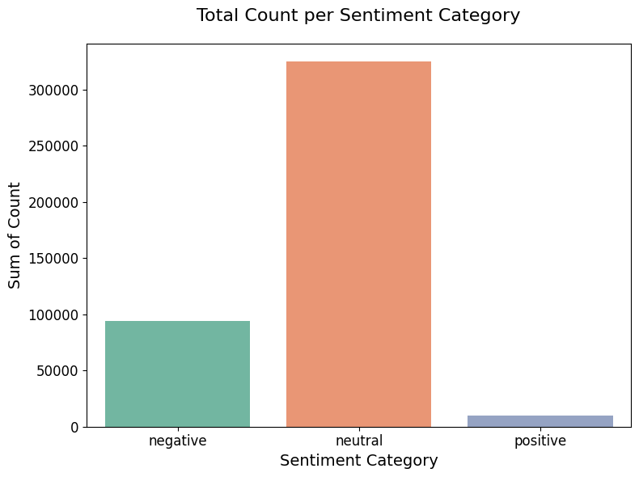

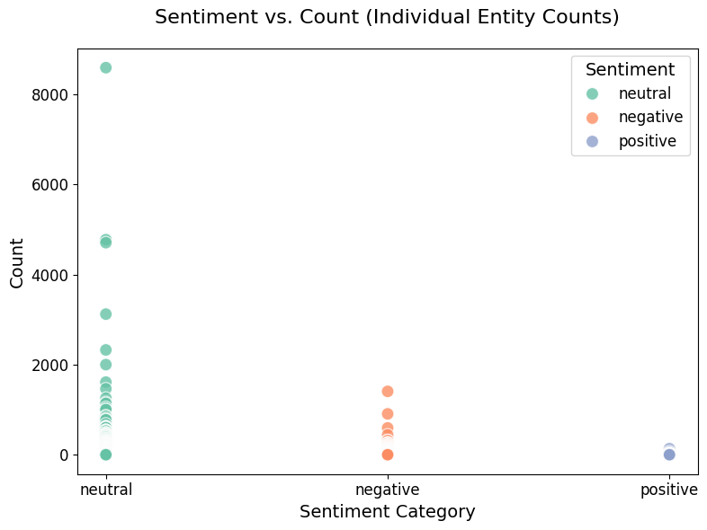

```python
import matplotlib.pyplot as plt
import seaborn as sns

# Define the custom color palette
colors = ['#66c2a5', '#fc8d62', '#8da0cb']

# Group sentiment counts and reset index
sentiment_counts = entity_sentiment_mapping.groupby('sentiment')['count'].sum().reset_index()

# Bar plot: Total Count per Sentiment Category
plt.figure(figsize=(8, 6))
sns.barplot(
    x='sentiment',
    y='count',
    data=sentiment_counts,
    palette=colors  # Apply custom colors
)
plt.title('Total Count per Sentiment Category', fontsize=16, pad=20)
plt.xlabel('Sentiment Category', fontsize=14)
plt.ylabel('Sum of Count', fontsize=14)
plt.xticks(fontsize=12)
plt.yticks(fontsize=12)
plt.tight_layout()
plt.show()

# Scatter plot: Sentiment vs. Count (Individual Entity Counts)
plt.figure(figsize=(8, 6))
sns.scatterplot(
    x='sentiment',
    y='count',
    data=entity_sentiment_mapping,
    hue='sentiment',
    palette=colors,  # Apply custom colors
    s=100,  # Set marker size for better visibility
    alpha=0.8  # Slight transparency for overlapping points
)
plt.title('Sentiment vs. Count (Individual Entity Counts)', fontsize=16, pad=20)
plt.xlabel('Sentiment Category', fontsize=14)
plt.ylabel('Count', fontsize=14)
plt.legend(title='Sentiment', fontsize=12, title_fontsize=14, loc='upper right')
plt.xticks(fontsize=12)
plt.yticks(fontsize=12)
plt.tight_layout()
plt.show()
```

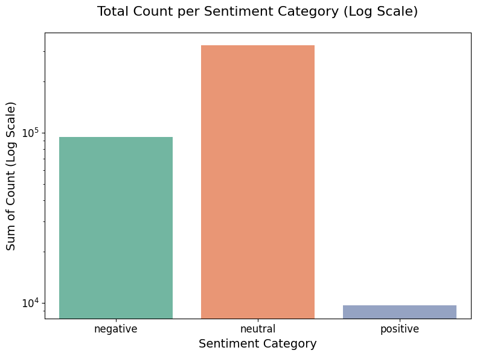

```python
import matplotlib.pyplot as plt
import seaborn as sns

# Define the custom color palette
colors = ['#66c2a5', '#fc8d62', '#8da0cb']  # Matching the color palette

# Create the bar plot
plt.figure(figsize=(8, 6))
sns.barplot(
    x='sentiment',
    y='count',
    data=sentiment_counts,
    palette=colors  # Apply custom colors
)

# Set y-axis to log scale
plt.yscale('log')

# Add title and axis labels with enhanced formatting
plt.title('Total Count per Sentiment Category (Log Scale)', fontsize=16, pad=20)
plt.xlabel('Sentiment Category', fontsize=14)
plt.ylabel('Sum of Count (Log Scale)', fontsize=14)

# Adjust tick label sizes
plt.xticks(fontsize=12)
plt.yticks(fontsize=12)

# Improve layout
plt.tight_layout()

# Show the plot
plt.show()
```

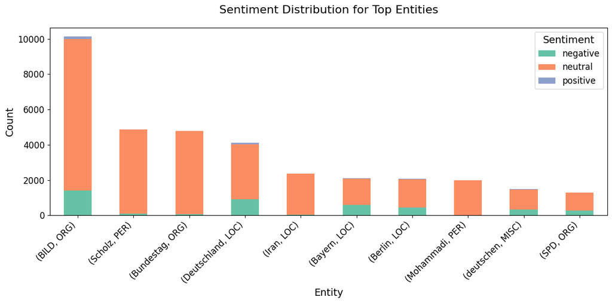

```python
import matplotlib.pyplot as plt

# Define the custom color palette
colors = ['#66c2a5', '#fc8d62', '#8da0cb']  # Matching the pie chart colors

# Group by entity and sentiment, then unstack for a stacked bar plot
entity_sentiment_counts = entity_sentiment_mapping.groupby(['entity', 'sentiment'])['count'].sum().unstack()

# Filter for entities with a large number of mentions (e.g., top 10)
top_entities = entity_sentiment_counts.sum(axis=1).nlargest(10).index
filtered_entity_sentiment_counts = entity_sentiment_counts.loc[top_entities]

# Create the stacked bar plot
ax = filtered_entity_sentiment_counts.plot(
    kind='bar',
    stacked=True,
    figsize=(12, 6),
    color=colors  # Apply custom colors
)

# Set title and labels with enhanced formatting
plt.title('Sentiment Distribution for Top Entities', fontsize=16, pad=20)
plt.xlabel('Entity', fontsize=14)
plt.ylabel('Count', fontsize=14)

# Rotate x-axis labels for better readability
plt.xticks(rotation=45, ha='right', fontsize=12)
plt.yticks(fontsize=12)

# Add a legend with a title
plt.legend(title='Sentiment', fontsize=12, title_fontsize=14, loc='upper right')

# Improve layout spacing
plt.tight_layout()

# Show the chart
plt.show()
```

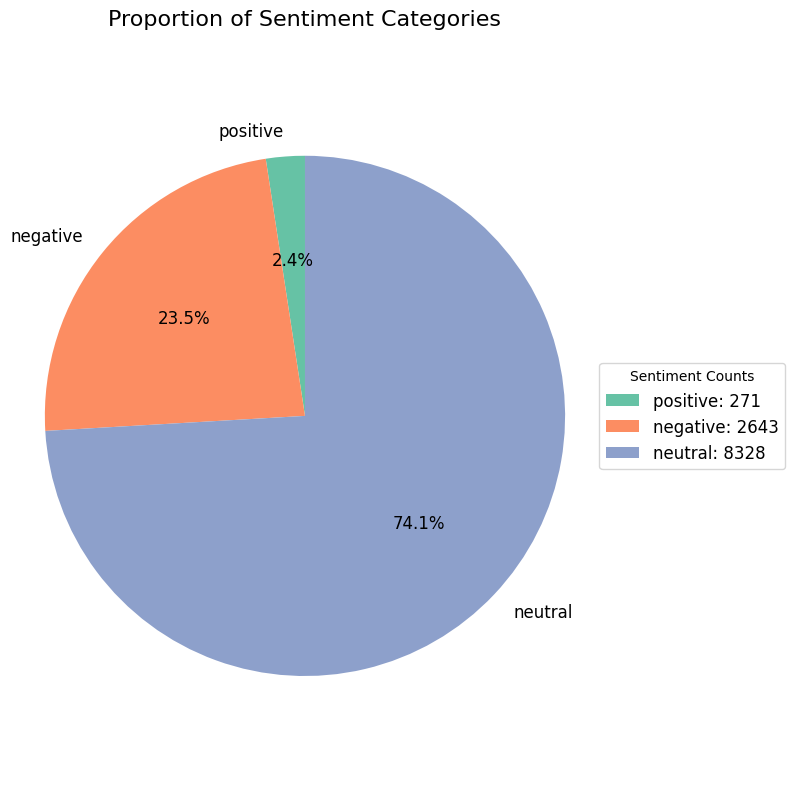

```python
import matplotlib.pyplot as plt
import pandas as pd

# Data
sentiment_counts = pd.DataFrame({
    'sentiment': ['positive', 'negative', 'neutral'],
    'count': [271, 2643, 8328]
})

# Create the figure
fig, ax = plt.subplots(figsize=(8, 8))  # Set figure size

# Define colors for the pie chart
colors = ['#66c2a5', '#fc8d62', '#8da0cb']  # Custom colors for better aesthetics

# Create the pie chart
wedges, texts, autotexts = ax.pie(
    sentiment_counts['count'],
    labels=sentiment_counts['sentiment'],
    autopct='%1.1f%%',
    startangle=90,
    colors=colors,
    textprops={'fontsize': 12}  # Font size for labels
)

# Add a legend showing absolute counts
ax.legend(
    wedges,
    [f"{label}: {count}" for label, count in zip(sentiment_counts['sentiment'], sentiment_counts['count'])],
    title="Sentiment Counts",
    loc="center left",
    bbox_to_anchor=(1, 0, 0.5, 1),  # Positioning the legend outside the pie chart
    fontsize=12
)

# Set title with increased font size
ax.set_title('Proportion of Sentiment Categories', fontsize=16, pad=20)

# Ensure pie is drawn as a circle
ax.axis('equal')

# Adjust layout for better spacing
plt.tight_layout()

# Show the chart
#plt.show()
plt.savefig("pieGraph.svg", format="svg")
```

## Topic Extraction

```python
# Define topic keywords
topic_keywords = {
    "Economy": ["Wirtschaft", "Finanzen", "Markt", "Börse", "Inflation", "Investitionen"],
    "Politics": ["Politik", "Regierung", "Partei", "Gesetz", "Minister"],
    "Climate": ["Klima", "Umwelt", "Energie", "Treibhausgase", "Klimawandel"],
    "Technology": ["Technologie", "Digitalisierung", "KI", "Cybersecurity"],
    "Sports": ["Sport", "Fußball", "Olympia", "Tor", "Mannschaft"],
    "Health": ["Gesundheit", "Medizin", "Pandemie", "Krankenhaus", "Pflege"],
    "Culture": ["Kultur", "Kino", "Musik", "Theater", "Kunst"],
    "Crime": ["Kriminalität", "Polizei", "Verbrechen", "Gericht", "Mord"],
    "Beauty": ["Schönheit", "Kleidung", "Schminken", "Make-up", "Schmuck"]
}

# Function to assign topics
def assign_topic(text):
    for topic, keywords in topic_keywords.items():
        if any(keyword in text for keyword in keywords):
            return topic
    return "other"

# Create a new dataframe with topics
df_topic_sentiment = df_sentiment[['maintext', 'sentiment']].copy()
df_topic_sentiment['topic'] = df_topic_sentiment['maintext'].apply(assign_topic)

# Inspect the new dataframe
df_topic_sentiment.head()
```

|  | maintext | sentiment | topic |
| --- | --- | --- | --- |
| 0 | Stammplatz weg, ungewisse Zukunft. Sportlich l... | negative | Sports |
| 1 | Frohes Neues liebe BILDplus-User! Damit der St... | neutral | Sports |
| 2 | Tennis-Start ins Neue Jahr! In Australien spie... | negative | Sports |
| 3 | Dieser Start in 2024 hat es in sich!\nHeute ha... | negative | Sports |
| 4 | Muss Europa JETZT drastisch aufrüsten?\nKreml-... | neutral | Economy |

```python
import pandas as pd

# Create a new dataframe with the desired structure
df_topic_sentiment_pivot = pd.pivot_table(df_topic_sentiment,
                                          index='topic',
                                          columns='sentiment',
                                          values='maintext',
                                          aggfunc='count',
                                          fill_value=0) #fill_value fills NaN with 0

# Reset the index to make 'topic' a regular column
df_topic_sentiment_pivot = df_topic_sentiment_pivot.reset_index()

# Display the resulting DataFrame
df_topic_sentiment_pivot
```

| sentiment | topic | negative | neutral | positive |
| --- | --- | --- | --- | --- |
| 0 | Beauty | 26 | 65 | 4 |
| 1 | Climate | 144 | 394 | 8 |
| 2 | Crime | 178 | 808 | 3 |
| 3 | Culture | 100 | 413 | 26 |
| 4 | Economy | 256 | 895 | 14 |
| 5 | Health | 136 | 437 | 9 |
| 6 | Politics | 306 | 1337 | 9 |
| 7 | Sports | 885 | 2392 | 120 |
| 8 | Technology | 47 | 97 | 3 |
| 9 | other | 565 | 1490 | 75 |

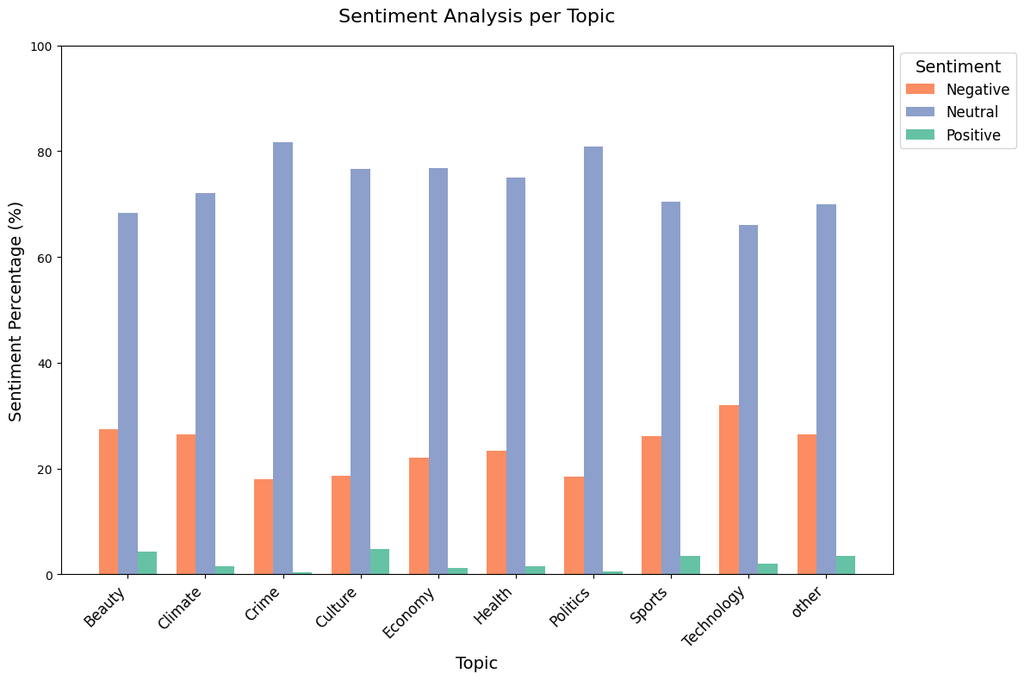

```python
import matplotlib.pyplot as plt
import pandas as pd

# Assuming df_topic_sentiment_pivot is already defined
# Calculate total sentiment counts for each topic
df_topic_sentiment_pivot['total'] = df_topic_sentiment_pivot['negative'] + df_topic_sentiment_pivot['neutral'] + df_topic_sentiment_pivot['positive']

# Calculate percentages for each sentiment
df_topic_sentiment_pivot['negative_percent'] = (df_topic_sentiment_pivot['negative'] / df_topic_sentiment_pivot['total']) * 100
df_topic_sentiment_pivot['neutral_percent'] = (df_topic_sentiment_pivot['neutral'] / df_topic_sentiment_pivot['total']) * 100
df_topic_sentiment_pivot['positive_percent'] = (df_topic_sentiment_pivot['positive'] / df_topic_sentiment_pivot['total']) * 100

# Define colors for better aesthetics
colors = ['#fc8d62', '#8da0cb', '#66c2a5']

# Create the figure
fig, ax = plt.subplots(figsize=(12, 8))  # Set figure size

# Bar width and index for grouping
bar_width = 0.25
index = range(len(df_topic_sentiment_pivot))

# Create bars for each sentiment
bars_negative = ax.bar(index, df_topic_sentiment_pivot['negative_percent'], bar_width, label='Negative', color=colors[0])
bars_neutral = ax.bar([i + bar_width for i in index], df_topic_sentiment_pivot['neutral_percent'], bar_width, label='Neutral', color=colors[1])
bars_positive = ax.bar([i + 2 * bar_width for i in index], df_topic_sentiment_pivot['positive_percent'], bar_width, label='Positive', color=colors[2])

# Set axis labels and title
ax.set_xlabel('Topic', fontsize=14)
ax.set_ylabel('Sentiment Percentage (%)', fontsize=14)
ax.set_title('Sentiment Analysis per Topic', fontsize=16, pad=20)

# Set x-ticks and rotate for readability
ax.set_xticks([i + bar_width for i in index])
ax.set_xticklabels(df_topic_sentiment_pivot['topic'], rotation=45, ha='right', fontsize=12)

# Set y-axis limit to 100
ax.set_ylim(0, 100)

# Add legend
ax.legend(title="Sentiment", fontsize=12, title_fontsize=14, loc="upper left", bbox_to_anchor=(1, 1))

# Adjust layout for better spacing
plt.tight_layout()

# Show the chart
plt.savefig("barGraphPercentage.svg", format="svg")  # Save the chart as an SVG
plt.show()
```

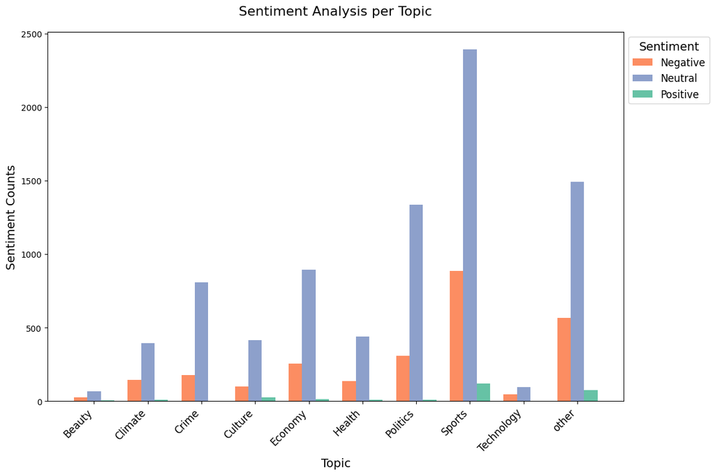

```python
import matplotlib.pyplot as plt
import pandas as pd

# Assuming df_topic_sentiment_pivot is already defined
# Calculate total sentiment counts for each topic
df_topic_sentiment_pivot['total'] = df_topic_sentiment_pivot['negative'] + df_topic_sentiment_pivot['neutral'] + df_topic_sentiment_pivot['positive']

# Define colors for better aesthetics
colors = ['#fc8d62', '#8da0cb', '#66c2a5']

# Create the figure
fig, ax = plt.subplots(figsize=(12, 8))  # Set figure size

# Bar width and index for grouping
bar_width = 0.25
index = range(len(df_topic_sentiment_pivot))

# Create bars for each sentiment
bars_negative = ax.bar(index, df_topic_sentiment_pivot['negative'], bar_width, label='Negative', color=colors[0])
bars_neutral = ax.bar([i + bar_width for i in index], df_topic_sentiment_pivot['neutral'], bar_width, label='Neutral', color=colors[1])
bars_positive = ax.bar([i + 2 * bar_width for i in index], df_topic_sentiment_pivot['positive'], bar_width, label='Positive', color=colors[2])

# Set axis labels and title
ax.set_xlabel('Topic', fontsize=14)
ax.set_ylabel('Sentiment Counts', fontsize=14)
ax.set_title('Sentiment Analysis per Topic', fontsize=16, pad=20)

# Set x-ticks and rotate for readability
ax.set_xticks([i + bar_width for i in index])
ax.set_xticklabels(df_topic_sentiment_pivot['topic'], rotation=45, ha='right', fontsize=12)

# Add legend
ax.legend(title="Sentiment", fontsize=12, title_fontsize=14, loc="upper left", bbox_to_anchor=(1, 1))

# Adjust layout for better spacing
plt.tight_layout()

# Show the chart
plt.savefig("barGraph.svg", format="svg")  # Save the chart as an SVG
plt.show()
```

## NER Network Analysis Section

### What's going on here

These 3 functions are the foundations of the NER network analysis. Here's a brief explaination:

#### Extract_entities

This function is called once on all the dataframe, and it's used to extract all of the entities present in the newpaper articles. It returns a list of entities

#### Extract_entity_pairs

This function combines the entities in list of two entities, actually extracting what will become the edges of the graph

#### Generate_network_graph

The main function that creates a graph of the entities. It functions as follows:

##### First two filters

A first filter is passed if we have an entity to analyze, and it filters the entire dataframe. Then, a second filter is passed according to the conditions, which is a lambda passed as a parameter. Conditions will be specified in future functions

##### Pair the entities

We pair the entities using the function above extract_entity_pairs. We're left with a list

##### Create a new dataframe out of the list, sort the pairs in alphabetical order, then add a weight to the graph

Which means that the weight of a node will be heavier the more times the relationship is mentioned

##### Visualize the graph

First we create a networkx graph to visualize it, but to have a better experience we include the pyvis library

##### Add degree centrality

To have a better insight of how connected a node is, we included node centrality. The bar plot that's left is sorted from the most named entity

```python
def extract_entities(text):
    doc = nlp(text)
    sent_entities=[]
    entity_labels = ['GPE', 'ORG','PER', 'LOC'] # we want to focus only on these entity types
    for sent in doc.sents:
        sent_entities += [ent.text for ent in sent.ents if ent.label_ in entity_labels]
    return sent_entities


def extract_entity_pairs(sent_entities):
    entity_pairs = list(combinations(sent_entities, 2))
    return entity_pairs


def generate_network_graph(conditions, entity=None):
    filtered_df = df
    if entity is not None:
        filtered_df = df[df['entities'].apply(lambda x: entity in x if isinstance(x, list) else False)]
    gen = filtered_df.loc[df.apply(conditions, axis=1), 'entities']

    entity_pairs = []
    for entities in gen:
        if isinstance(entities, list):  # Make sure we handle lists correctly
            entity_pairs += extract_entity_pairs(entities)


    entity_pairs_df = pd.DataFrame(entity_pairs, columns=["source","target"])
    entity_pairs_df = pd.DataFrame(np.sort(entity_pairs_df.values, axis = 1), columns = entity_pairs_df.columns)
    # Let's add the value column so to add weight
    entity_pairs_df["value"] = 1
    entity_pairs_df = entity_pairs_df.groupby(["source","target"], sort=False, as_index=False).sum()

    # Create a graph from a pandas dataframe
    G = nx.from_pandas_edgelist(entity_pairs_df,
                                source = "source",
                                target = "target",
                                edge_attr = "value",
                                create_using = nx.Graph())

    # Add edges to the graph
    G.add_edges_from(entity_pairs)

    net = Network(notebook = True, width="1000px", height="700px", bgcolor='#222222', font_color='white', cdn_resources='remote', select_menu=True)

    node_degree = dict(G.degree)

    #Setting up node size attribute
    nx.set_node_attributes(G, node_degree, 'size')

    net.from_nx(G)
    net.show("mygraph.html")
    net.save_graph("mygraph.html")

    # degree centrality, this will do a research on the topic that's most talked about

    degree_dict = nx.degree_centrality(G)
    degree_df = pd.DataFrame.from_dict(degree_dict, orient='index', columns=['centrality'])
    degree_df.sort_values('centrality', ascending= False)[0:9].plot(kind="bar")
```

### The get_network and get_entity functions

These functions help us retrieve information more easily. Here we specify the conditions used in the generate_network_graph function. They help us retrieve, from top to bottom:

- A network of entities mentioned by a particular journalist;
- A network of entities mentioned in a span of time
- A network of entities mentioned in a span of time, with another entity filter on top
- A network of entities related to a particular topic

Then the last function doesn't generate a network graph, but creates a plot on how many times an entity was mentioned throughout the weeks

```python
df_network = df.copy()
def get_network_by_author(author):
    conditions = lambda row: author in row['authors']
    generate_network_graph(conditions)

def get_network_by_date(date_from= None, date_to=None ):
    conditions = lambda row: date_from <= row['date_publish'] <= date_to
    generate_network_graph(conditions)

def get_entity_by_date(date_from = None, date_to = None, entity = None):
    conditions = lambda row: date_from <= row['date_publish'] <= date_to
    generate_network_graph(conditions, entity)

def get_network_by_topic(topic):
    conditions = lambda row: topic in row['topic']
    generate_network_graph(conditions)

def get_entity_over_time(entity):
    filtered_df = df_network[df_network['entities'].apply(lambda x: entity in x if isinstance(x, list) else False)]

    weekly_counts = filtered_df.groupby(pd.Grouper(key='date_publish', freq='W')).size()

    # Plot the data
    plt.figure(figsize=(10, 6))
    weekly_counts.plot(kind='line', marker='o', label=entity, color='blue')
    plt.gca().yaxis.set_major_locator(MaxNLocator(integer=True))


    # Add labels and title
    plt.title(f"Occurrences of {entity} Over Time", fontsize=16)
    plt.xlabel("Date", fontsize=14)
    plt.ylabel("Count", fontsize=14)
    plt.grid(True)
    plt.legend()

    return filtered_df
```

```python
import matplotlib.pyplot as plt
import pandas as pd
from matplotlib.ticker import MaxNLocator

# Define the custom color palette for consistency
custom_colors = ['#66c2a5', '#fc8d62', '#8da0cb']

df_network = df.copy()

def generate_network_graph(conditions, entity=None):
    # Placeholder function for generating network graphs.
    # Ensure you apply the `custom_colors` palette when plotting.
    pass

def get_network_by_author(author):
    conditions = lambda row: author in row['authors']
    generate_network_graph(conditions)

def get_network_by_date(date_from=None, date_to=None):
    conditions = lambda row: date_from <= row['date_publish'] <= date_to
    generate_network_graph(conditions)

def get_entity_by_date(date_from=None, date_to=None, entity=None):
    conditions = lambda row: date_from <= row['date_publish'] <= date_to
    generate_network_graph(conditions, entity)

def get_network_by_topic(topic):
    conditions = lambda row: topic in row['topic']
    generate_network_graph(conditions)

def get_entity_over_time(entity):
    filtered_df = df_network[df_network['entities'].apply(lambda x: entity in x if isinstance(x, list) else False)]

    weekly_counts = filtered_df.groupby(pd.Grouper(key='date_publish', freq='W')).size()

    # Plot the data
    plt.figure(figsize=(10, 6))
    weekly_counts.plot(kind='line', marker='o', label=entity, color=custom_colors[0])  # Use custom palette for line color
    plt.gca().yaxis.set_major_locator(MaxNLocator(integer=True))

    # Add labels and title
    plt.title(f"Occurrences of {entity} Over Time", fontsize=16)
    plt.xlabel("Date", fontsize=14)
    plt.ylabel("Count", fontsize=14)
    plt.grid(True, linestyle='--', alpha=0.7)  # Match grid style with the pie chart
    plt.legend()

    # Save the plot as SVG
    plt.tight_layout()
    plt.savefig(f"{entity}_occurrences_over_time.svg", format="svg")

    return filtered_df
```

As mentioned before, we need to extract once every entity present in the dataframe

```python
df['entities'] = df['maintext'].apply(extract_entities)
```

Now, let's say we want to research about Olaf Scholz, how much Bild talked about him and when, and with whom. We can start our analysis by seeing how much he was mentioned over time in a newspaper article

```python
df_network['entities'] = df['entities']
```

[output not shown]

615 rows × 8 columns

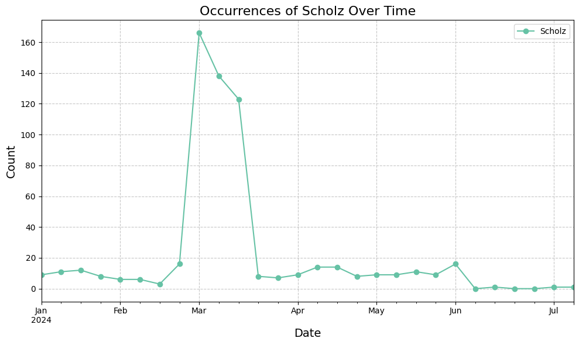

```python
get_entity_over_time('Scholz')
```

We notice that the results are pretty much stable at around 10-20 points until we reach a peak from the end of february until mid-march. Now let's do a search on the entities relevant around him, in that span of time

[output not shown]

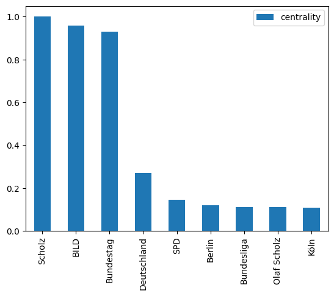

```python
start = pd.Timestamp(2024, 2,20)
end = pd.Timestamp(2024, 3, 21)
get_entity_by_date(start, end, 'Scholz')
```

This is only one example that explains why the newspaper chose to keep talking about him

```python
!python -m spacy download de_core_news_md
```

[output not shown]

```python
!pip install wordcloud
```

```python
!pip install datasets
```

[output not shown]

```python
!pip install datasets
```

```python
!pip install germansentiment
```

```
Downloading germansentiment-1.1.0-py3-none-any.whl (5.8 kB)
```

```python
!pip install pyvis
```

```
Downloading pyvis-0.3.2-py3-none-any.whl (756 kB)
   ━━━━━━━━━━━━━━━━━━━━━━━━━━━━━━━━━━━━━━━━ 756.0/756.0 kB 28.6 MB/s eta 0:00:00
Downloading jedi-0.19.2-py2.py3-none-any.whl (1.6 MB)
   ━━━━━━━━━━━━━━━━━━━━━━━━━━━━━━━━━━━━━━━━ 1.6/1.6 MB 70.1 MB/s eta 0:00:00
```

```python
!pip list
```